# Gráficos del Modelo Económico

Daniel Encinas Zevallos [^1]

*Este es un documento de R Markdown. Markdow es una sintaxis simple para hacer formatos en HTML, PDF y documentos de MS Word. Para mayores detalles, ingresar a http://rmarkdown.rstudio.com.*

# Paquetes de R

```r
library(tidyverse)
library(gganimate)
library(gifski)
library(av)
library(patchwork)
library(scales)
library(gridExtra)
library(grDevices)
library(ggthemes)
library(magick)
library(extrafont)
library(viridis)
library(hrbrthemes)
library(stringi)
```

#PBI 1922-2021

El repositorio incluye un folder de [Data](https://github.com/danielencinaszevallos/modelo_peru_graphs/tree/main/data) donde se pueden descargar todas las bases de datos en formato .xlxs o .csv. Al mismo tiempo, los documentos .csv son llamados aquí directamente del *raw link* usando la función `read.csv`.

Para empezar, el siguiente código carga la data para el PBI del Perú entre 1922 y 2021 (el año base es 2007). Además, uso `mutate` para crear una variable *lag* (correspondiente al año anterior) y una variable de cambio porcentual.

```r
pbi_peru <-
  read.csv(
    "https://raw.githubusercontent.com/danielencinaszevallos/modelo_peru_graphs/main/data/modelo_pbi_peru.csv"
  ) %>%
  mutate(
    lag_pbi = lag(PBI_2007_BASE),
    cambio_por = (PBI_2007_BASE - lag_pbi)/PBI_2007_BASE * 100
  )
```

```r
pbi_1 <-ggplot(pbi_peru) +
  geom_area(aes(x = YEAR, y = PBI_2007_BASE / 100), fill = "magenta4") + #Dividido entre mil
  ggthemes::theme_fivethirtyeight() +
  scale_y_continuous(name="", limits = c(0, 5500)) + #Eje Y en blanco
  scale_x_continuous(
    name = "Año",
    limits = c(1922, 2023),
    breaks = scales::pretty_breaks(n = 10)
  ) +
  labs(title = "PBI 1922-2021 (Totales)",
       subtitle= "Año base 2007") +
    theme(axis.title = element_text()) #Esta capa cambia el default de tema que no acepta texto en ejes
```

```r
pbi_2 <-ggplot(pbi_peru) +
  geom_line(aes(x = YEAR, y = cambio_por), linewidth=1, color="green3") +
  ggthemes::theme_fivethirtyeight() +
  scale_y_continuous(name="") + #Eje Y en blanco
  scale_x_continuous(
    name = "Año",
    limits = c(1922, 2023),
    breaks = scales::pretty_breaks(n = 10)
  ) +
  labs(title = "PBI 1922-2021 (Variación Porcentual)",
       subtitle = "Cambio porcentual de un año a otro",
       caption = "Elaboración: @somospuenteperu") +
    theme(axis.title = element_text()) #Esta capa cambia el default de tema que no acepta texto en ejes
```

La función `grid.arrange` del paquete GridExtra permite colocar los dos gráficos de arriba uno encima del otro.

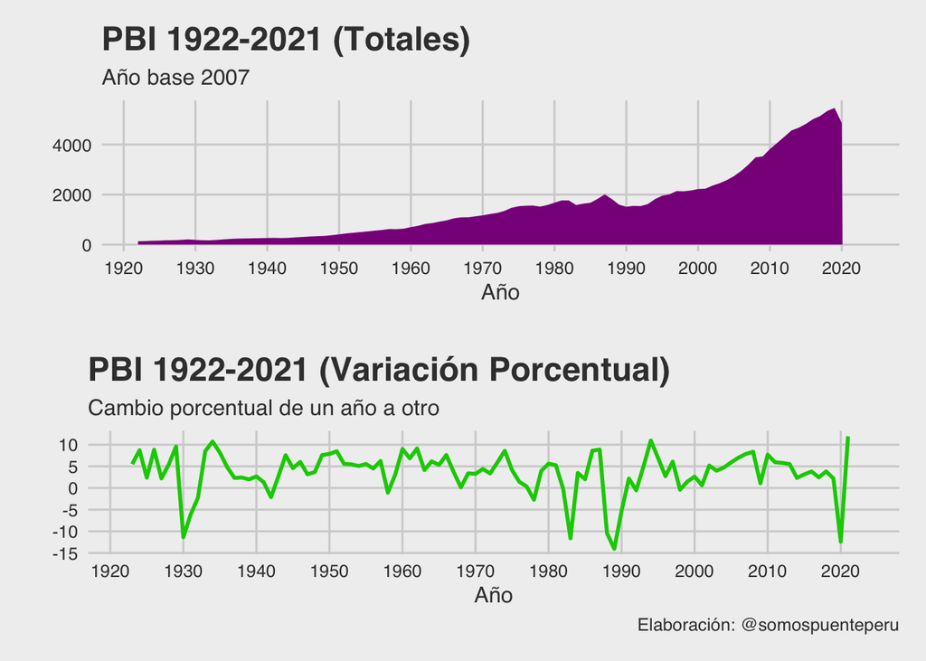

```r
grid.arrange(pbi_1,pbi_2, nrow=2, ncol=1)
```

Finalmente, guardo estos gráficos directamente en la computadora con la función `jpeg` del paquete grDevices. Cambio algunos parámetros para asegurar una alta resolución.

```r
jpeg("pbi_peru.jpg", res=300, width = 8, height=8, units="in")
grid.arrange(pbi_1,pbi_2, nrow=2, ncol=1)
dev.off()
```

# Acceso a salud

Nuevamente, cargamos la data de acceso a la salud desde el repositorio de Github.

```r
salud <- read.csv("https://raw.githubusercontent.com/danielencinaszevallos/modelo_peru_graphs/main/data/modelo_acceso%20a%20la%20salud.csv")
```

El nombre las columnas tiene algunos caracteres extraños. Para corregirlo, uso la función `colnames` de R básico. Asimismo, acorto el nombre de dos regiones para ayudar a su visualización.

```r
colnames(salud) <-c("ID", "region", 2008:2020)
salud$region[7] <-"Callao"
salud$region[16] <-"L.Metropolitana"
```

El formato de la base de datos puede complicar la visualización. Por eso, uso la función `pivot_longer` del paquete dplyr para convertir la data de formato ancho a formato largo. Es decir, ahora hay menos columnas pero más filas.

```r
salud_longer<-pivot_longer(salud, #Base de datos
             cols = c(-ID, -region, `2008`:`2020`), #Columnas ID y región quedan iguales
             names_to = "year", #El resto de nombres de columnas son ahora valores de la nueva columna "year".
             values_to = "value") #Los valores ahora aparecen en una tercera columna "value"
```

Finalmente, creo un gráfico con `ggplot` que toma como eje x el año, eje y el valor del año y que además está agrupado por región. El `geom_point` indica la creación de puntos y `geom_line` de líneas, ambos con una paleta de colores de `scale_color_viris`.

El código añade otros detalles de estilo que son especificados en como comentarios en el código de abajo. Nuevamente, uso el tema `theme_fivethirtyeight` del paquete ggthemes. Sin embargo, modifico algunos aspectos de este tema con la función `theme`. Finalmente, `facets_wrap` crea un gráfico por cada región y `labs` permite especificar etiquetas generales de título, subtítulo y leyenda.

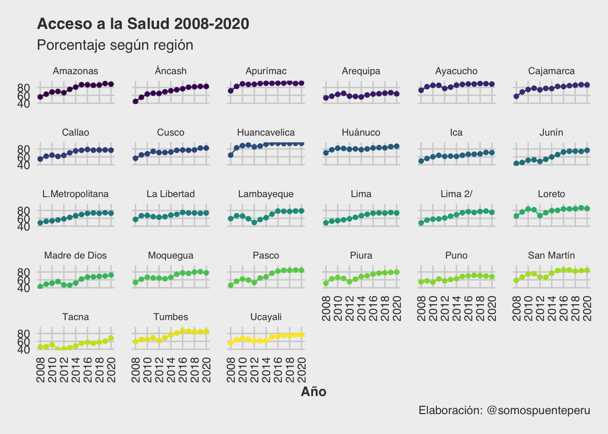

```r
salud_grafico <- ggplot(salud_longer, aes(x = year, y = value*100, group = region)) +
  geom_point(aes(color=region)) +
  geom_line(aes(color=region)) +
  scale_color_viridis(discrete = TRUE) +
  ggthemes::theme_fivethirtyeight() +
  facet_wrap( ~ region) +
  theme(
    legend.position = "none",
    #Elimina la leyenda general por color y grupo

    panel.spacing = unit(1, "lines"),
    #Añade espacio entre los plots

    strip.text.x = element_text(size = 8),
    #Especifica el tamaño del texto en el eje x

    plot.title = element_text(size = 13),
    #Especifica el tamaño del título del gráfico

    axis.title.x = element_text(size = 11, face="bold")
    #Espeficia el tamaño y estilo del título del eje x

  ) +
  scale_x_discrete(guide = guide_axis(angle = 90),
                   #El texto del eje x ahora está a 90 grados

                   breaks = scales::pretty_breaks(n = 5),
                   #Limita a 5 el número de quiebres en el eje

                   name="Año") +
                   #Especifica el título del eje

  labs(title = "Acceso a la Salud 2008-2020",
       subtitle = "Porcentaje según región",
       caption = "Elaboración: @somospuenteperu")

salud_grafico
```

Como hice anteriormente, guardo el gráfico en alta resolución.

```r
jpeg("salud_grafico.jpg", res=300, width = 8, height=8, units="in")
salud_grafico
dev.off()
```

# Alumbrado Público

Otra vez seguimos los mismos pasos. Primero, cargamos la data.

```r
alumbrado <- read.csv("https://raw.githubusercontent.com/danielencinaszevallos/modelo_peru_graphs/main/data/modelo_alumbrado%20pub..csv")
```

A continuación, corregimos nuevamente nombres de columnas y acortamos nombres de región.

```r
colnames(alumbrado) <-c("ID", "region", 2009:2019)
alumbrado$region[15] <-"Lima"
alumbrado$region[16] <-"Prov.Lima"
alumbrado$region[17] <-"Reg.Lima"
alumbrado$region[7] <-"Callao"
```

Igualmente, cambio el formato de la data de ancho a largo.

```r
alumbrado_longer<-pivot_longer(alumbrado, #Base de datos
             cols = c(-ID, -region, `2009`:`2019`), #Columnas ID y región quedan iguales
             names_to = "year", #El resto de nombres de columnas son ahora valores de la nueva columna "year".
             values_to = "value") #Los valores ahora aparecen en una tercera columna "value"
```

Finalmente, hago nuevamente una imagen con múltiples gráficos de líneas y puntos (uno por región).

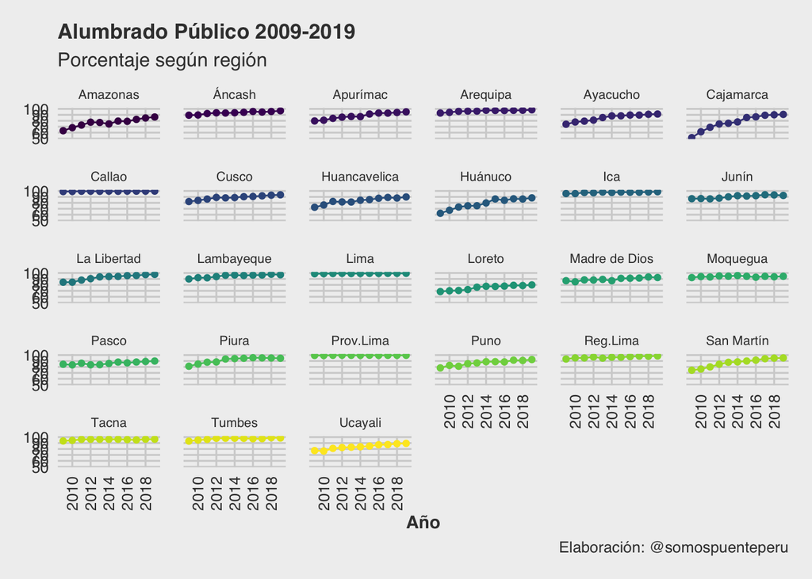

```r
alumbrado_grafico <- ggplot(alumbrado_longer, aes(x = year, y = value, group = region)) +
  geom_point(aes(color=region)) + #Gráfico de dispersión
  geom_line(aes(color=region)) + #Gráfico de líneas
  scale_color_viridis(discrete = TRUE) + #Paleta de colores
  ggthemes::theme_fivethirtyeight() + #Tema
  facet_wrap( ~ region) + #Modificaciones al tema
  theme(
    legend.position = "none",
    #Elimina la leyenda general por color y grupo

    panel.spacing = unit(1, "lines"),
    #Añade espacio entre los plots

    strip.text.x = element_text(size = 8),
    #Especifica el tamaño del texto en el eje x

    plot.title = element_text(size = 13),
    #Especifica el tamaño del título del gráfico

    axis.title.x = element_text(size = 11, face="bold")
    #Espeficia el tamaño y estilo del título del eje x

  ) +
  scale_x_discrete(guide = guide_axis(angle = 90),
                   #El texto del eje x ahora está a 90 grados

                   breaks = scales::pretty_breaks(n = 5),
                   #Limita a 5 el número de quiebres en el eje

                   name="Año") +
                   #Especifica el título del eje

  labs(title = "Alumbrado Público 2009-2019",
       #Título

       subtitle = "Porcentaje según región",
       #Subtítulo

       caption = "Elaboración: @somospuenteperu")
       #Leyenda

alumbrado_grafico
```

Como hice anteriormente, guardo el gráfico en alta resolución.

```r
jpeg("alumbrado_grafico.jpg", res=300, width = 8, height=8, units="in")
alumbrado_grafico
dev.off()
```

# Años de educación

Nuevamente, hacemos todo el mismo procedimiento con la data de educación.

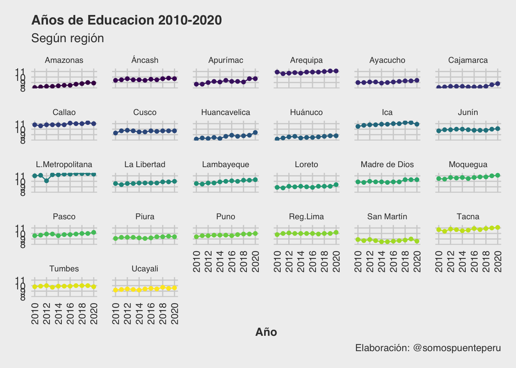

```r
educacion <- read.csv("https://raw.githubusercontent.com/danielencinaszevallos/modelo_peru_graphs/main/data/modelo_a%C3%B1os%20-%20educaci%C3%B3n.csv")

colnames(educacion) <-c("ID", "region", 2010:2020)
educacion$region[15] <-"L.Metropolitana"
educacion$region[16] <-"Reg.Lima"
educacion$region[7] <-"Callao"

educacion_longer<-pivot_longer(educacion, #Base de datos
             cols = c(-ID, -region, `2010`:`2020`), #Columnas ID y región quedan iguales
             names_to = "year", #El resto de nombres de columnas son ahora valores de la nueva columna "year".
             values_to = "value") #Los valores ahora aparecen en una tercera columna "value"

educacion_grafico <- ggplot(educacion_longer, aes(x = year, y = value, group = region)) +
  geom_point(aes(color=region)) + #Gráfico de dispersión
  geom_line(aes(color=region)) + #Gráfico de líneas
  scale_color_viridis(discrete = TRUE) + #Paleta de colores
  ggthemes::theme_fivethirtyeight() + #Tema
  facet_wrap( ~ region) + #Modificaciones al tema
  theme(
    legend.position = "none",
    #Elimina la leyenda general por color y grupo

    panel.spacing = unit(1, "lines"),
    #Añade espacio entre los plots

    strip.text.x = element_text(size = 8),
    #Especifica el tamaño del texto en el eje x

    plot.title = element_text(size = 13),
    #Especifica el tamaño del título del gráfico

    axis.title.x = element_text(size = 11, face="bold")
    #Espeficia el tamaño y estilo del título del eje x

  ) +
  scale_x_discrete(guide = guide_axis(angle = 90),
                   #El texto del eje x ahora está a 90 grados

                   breaks = scales::pretty_breaks(n = 5),
                   #Limita a 5 el número de quiebres en el eje

                   name="Año") +
                   #Especifica el título del eje

  labs(title = "Años de Educacion 2010-2020",
       #Título

       subtitle = "Según región",
       #Subtítulo

       caption = "Elaboración: @somospuenteperu")
       #Leyenda

educacion_grafico
```

Como hice anteriormente, guardo el gráfico en alta resolución.

```r
jpeg("educacion_grafico.jpg", res=300, width = 8, height=8, units="in")
educacion_grafico
dev.off()
```

# Años de nutricion

Nuevamente, hacemos todo el mismo procedimiento con la data de nutricion.

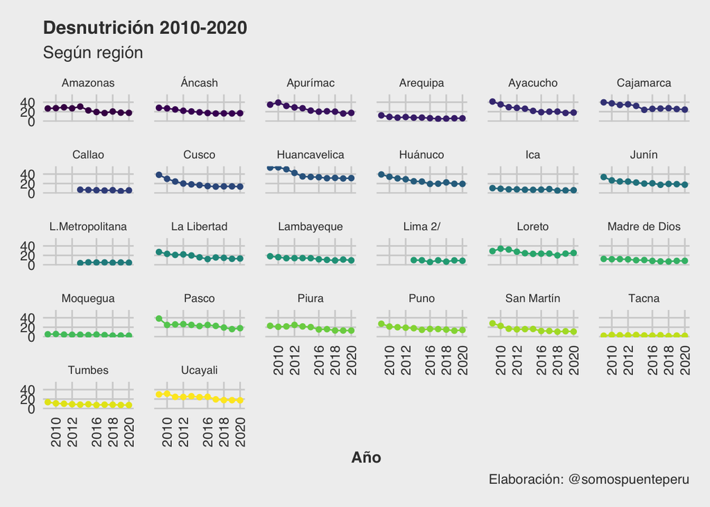

```r
nutricion <- read.csv("https://raw.githubusercontent.com/danielencinaszevallos/modelo_peru_graphs/main/data/modelo_desnutrici%C3%B3n.csv")

colnames(nutricion) <-c("ID", "region", 2009:2013, 2015:2020)

nutricion$region[15] <-"L.Metropolitana"
nutricion$region[16] <-"Lima 2/"
nutricion$region[7] <-"Callao"

nutricion<-lapply(nutricion, str_replace_all,  ",", ".") %>%
  lapply(stri_replace_all_fixed,  "(", "") %>%
  lapply(stri_replace_all_fixed,  ")", "") %>%
  lapply(str_replace_all,  "-", "NA") %>%
  as.data.frame()

colnames(nutricion) <-c("ID", "region", 2009:2013, 2015:2020)

nutricion2 <-nutricion %>%
   mutate(across(.cols = c(`2009`:`2013`,`2015`:`2020`),
                 .fns = as.double))
nutricion_longer<-pivot_longer(nutricion2, #Base de datos
             cols = c(-ID, -region, `2009`:`2013`,`2015`:`2020`), #Columnas ID y región quedan iguales
             names_to = "year", #El resto de nombres de columnas son ahora valores de la nueva columna "year".
             values_to = "value") #Los valores ahora aparecen en una tercera columna "value"

nutricion_grafico <- ggplot(nutricion_longer, aes(x = year, y = value, group = region)) +
  geom_point(aes(color=region)) + #Gráfico de dispersión
  geom_line(aes(color=region)) + #Gráfico de líneas
  scale_color_viridis(discrete = TRUE) + #Paleta de colores
  ggthemes::theme_fivethirtyeight() + #Tema
  facet_wrap( ~ region) + #Modificaciones al tema
  theme(
    legend.position = "none",
    #Elimina la leyenda general por color y grupo

    panel.spacing = unit(1, "lines"),
    #Añade espacio entre los plots

    strip.text.x = element_text(size = 8),
    #Especifica el tamaño del texto en el eje x

    plot.title = element_text(size = 13),
    #Especifica el tamaño del título del gráfico

    axis.title.x = element_text(size = 11, face="bold")
    #Espeficia el tamaño y estilo del título del eje x

  ) +
  scale_x_discrete(guide = guide_axis(angle = 90),
                   #El texto del eje x ahora está a 90 grados

                   breaks = scales::pretty_breaks(n = 5),
                   #Limita a 5 el número de quiebres en el eje

                   name="Año") +
                   #Especifica el título del eje

  labs(title = "Desnutrición 2010-2020",
       #Título

       subtitle = "Según región",
       #Subtítulo

       caption = "Elaboración: @somospuenteperu")
       #Leyenda

nutricion_grafico
```

Como hice anteriormente, guardo el gráfico en alta resolución.

```r
jpeg("nutricion_grafico.jpg", res=300, width = 8, height=8, units="in")
nutricion_grafico
dev.off()
```

# Otras alternativas de gráficos

```r
pbi_1_alt <-ggplot(pbi_peru) +
  geom_area(aes(x = YEAR, y = PBI_2007_BASE / 1000)) + #, fill = "magenta4") +
  theme(panel.grid.major.x = element_blank(),
        panel.grid.minor.x = element_blank()) +
  scale_y_continuous(name = "PBI (Miles)", limits = c(0, 550)) +
  scale_x_continuous(
    name = "Año",
    limits = c(1922, 2023),
    breaks = scales::pretty_breaks(n = 10)
  ) +
  labs(title = "PBI 1922-2021 (Totales)")
```

```r
pbi_2_alt <-ggplot(pbi_peru) +
  geom_line(aes(x = YEAR, y = cambio_por), linewidth=1) +
  theme_classic() +
  theme(panel.grid.major.x = element_blank(),
        panel.grid.minor.x = element_blank()) +
  scale_y_continuous(name = "PBI (Variación Porcentual)") +
  scale_x_continuous(
    name = "Año",
    limits = c(1922, 2023),
    breaks = scales::pretty_breaks(n = 10)
  ) +
  labs(title = "PBI 1922-2021 (Porcentaje)",
       caption = "Elaboración: @somospuenteperu")
```

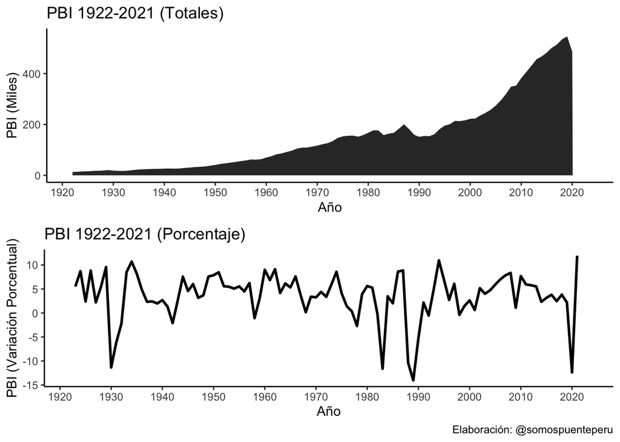

```r
grid.arrange(pbi_1_alt+theme_classic(),pbi_2_alt +theme_classic(), nrow=2, ncol=1)
```

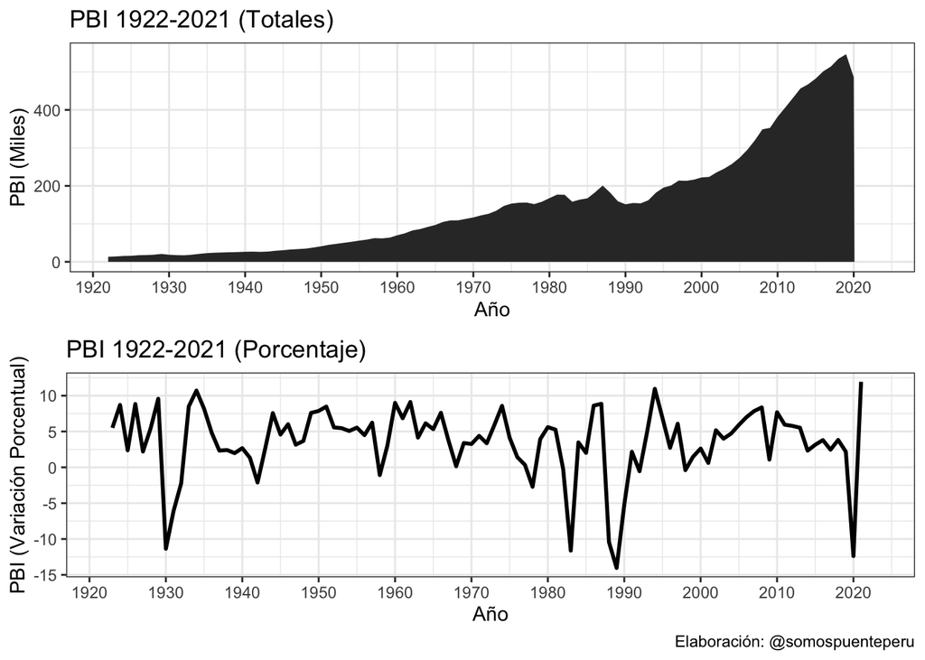

```r
grid.arrange(pbi_1_alt+theme_bw(),pbi_2_alt +theme_bw(), nrow=2, ncol=1) #Temática blanco y negro
```

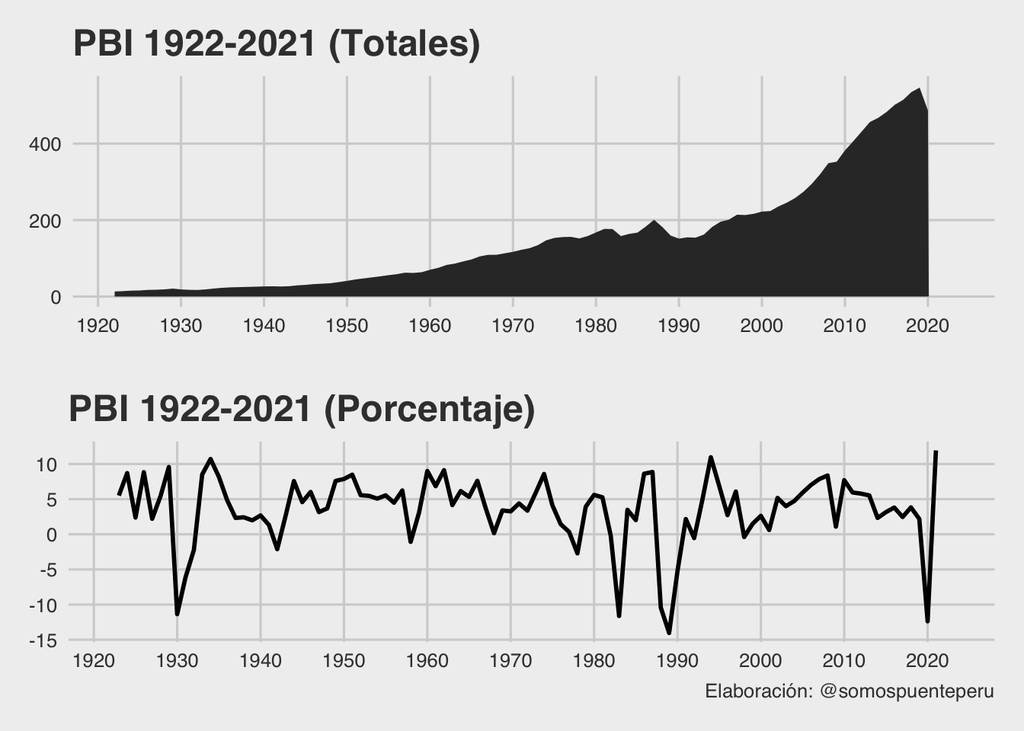

```r
grid.arrange(pbi_1_alt + ggthemes::theme_fivethirtyeight(), #Temática de fivethertyeight
             pbi_2_alt + ggthemes::theme_fivethirtyeight(), #Temática de fivethertyeight
             nrow=2, ncol=1)
```

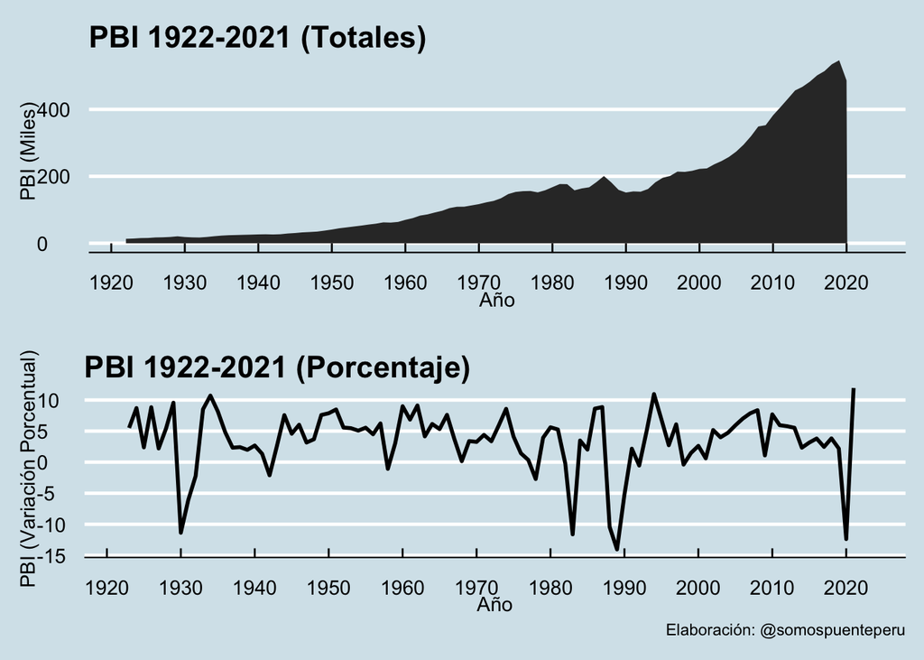

```r
grid.arrange(
  pbi_1_alt + ggthemes::theme_economist() + #Temática de The Economist
    ggthemes::scale_color_economist() +
    ggthemes::scale_fill_economist(),
  pbi_2_alt + ggthemes::theme_economist() + #Temática de The Economist
    ggthemes::scale_color_economist() +
    ggthemes::scale_fill_economist(),
  nrow = 2,
  ncol = 1
)
```

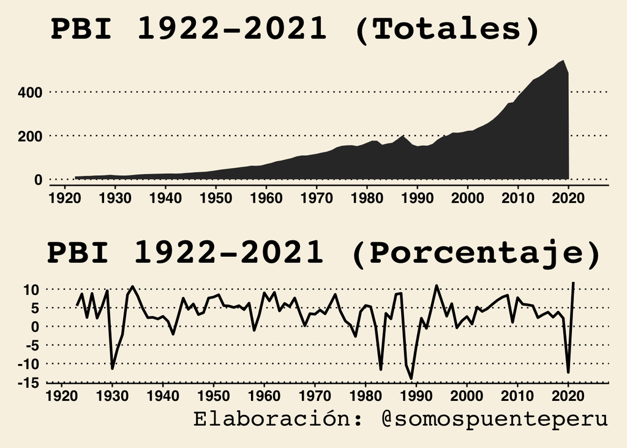

```r
grid.arrange(
  pbi_1_alt + ggthemes::theme_wsj() + #Temática del Wall Street Journal
    ggthemes::scale_color_wsj(),
  pbi_2_alt + ggthemes::theme_wsj() + #Temática del Wall Street Journal
    ggthemes::scale_color_wsj(),
  nrow = 2,
  ncol = 1
)
```

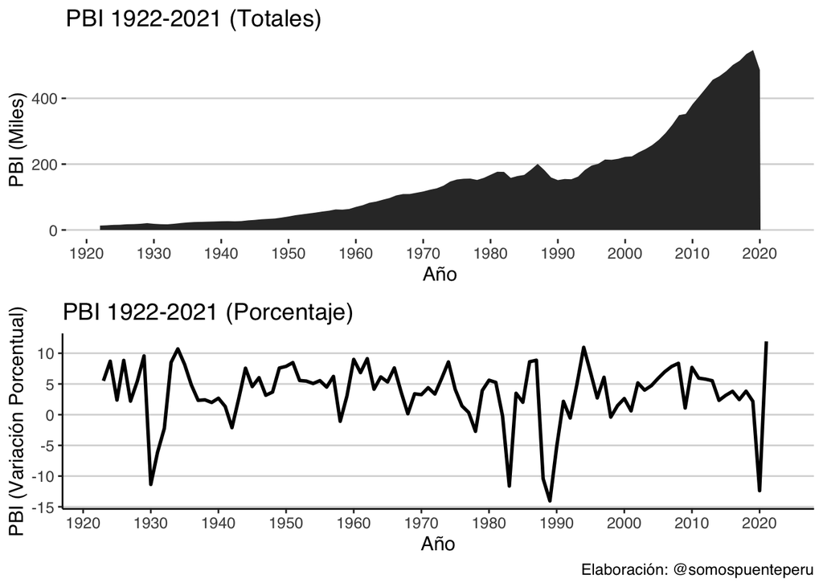

```r
grid.arrange(
  pbi_1_alt + ggthemes::theme_hc() + #Temática de High Charts
    ggthemes::scale_color_hc(),
  pbi_2_alt + ggthemes::theme_hc() + #Temática de High Charts
    ggthemes::scale_color_hc(),
  nrow = 2,
  ncol = 1
)
```

[^1]: Northwestern University / Puente Perú